# eda

gsk

16/12/2015

## Prudential Competition at Kaggle

## Exploratory Data Analysis

### Set up

```r
setwd(PATH)
train = read.table(file = './input/train.csv', header = T, sep = ',')
test = read.table(file = './input/test.csv', header = T, sep = ',')
all_data = rbind(train[, -128], test)
```

### Exploring the data set

#### Product_Info_1-7 A set of normalized variables relating to the product applied for

Structure of this group of data

```
## 'data.frame':    79146 obs. of  6 variables:
##  $ Product_Info_1: int  1 1 1 1 1 1 1 1 1 1 ...
##  $ Product_Info_2: Factor w/ 19 levels "A1","A2","A3",..: 17 1 19 18 16 16 8 16 17 19 ...
##  $ Product_Info_3: int  10 26 26 10 26 26 10 26 26 21 ...
##  $ Product_Info_4: num  0.0769 0.0769 0.0769 0.4872 0.2308 ...
##  $ Product_Info_5: int  2 2 2 2 2 3 2 2 2 2 ...
##  $ Product_Info_6: int  1 3 3 3 3 1 3 3 3 3 ...
```

```
##
## --- Product_Info_1 ---
## integer
##    Min. 1st Qu.  Median    Mean 3rd Qu.    Max.
##   1.000   1.000   1.000   1.026   1.000   2.000
## Table
##     1     2
## 77087  2059
```

a two class unbalanced variable (1 or 2). It should be converted to factor.

```
##
## --- Product_Info_2 ---
## factor
## Table
##    A1    A2    A3    A4    A5    A6    A7    A8    B1    B2    C1    C2
##  3219  3072  1564   263  1009  2733  1823  9140    85  1446   377   197
##    C3    C4    D1    D2    D3    D4    E1
##   437   291  8611  8344 18753 14071  3711
```

a factor of several unbalanced classes.

```
##
## --- Product_Info_3 ---
## integer
##    Min. 1st Qu.  Median    Mean 3rd Qu.    Max.
##    1.00   26.00   26.00   24.39   26.00   38.00
## Table
##     1     2     3     4     5     6     7     8     9    10    11    12
##     1    11     2    75     1     5     2    60    13  8123    63     2
##    13    14    15    16    17    18    19    20    21    22    23    24
##     1     1   331     1     4     1     2     1    19     1    12     4
##    25    26    27    28    29    30    31    32    33    34    35    36
##     1 67711     1    51  1757    91   567     2    11     3     1    31
##    37    38
##   182     1
```

```
##
## --- Product_Info_4 ---
## numeric
##    Min. 1st Qu.  Median    Mean 3rd Qu.    Max.
## 0.00000 0.07692 0.23080 0.32780 0.48720 1.00000
```

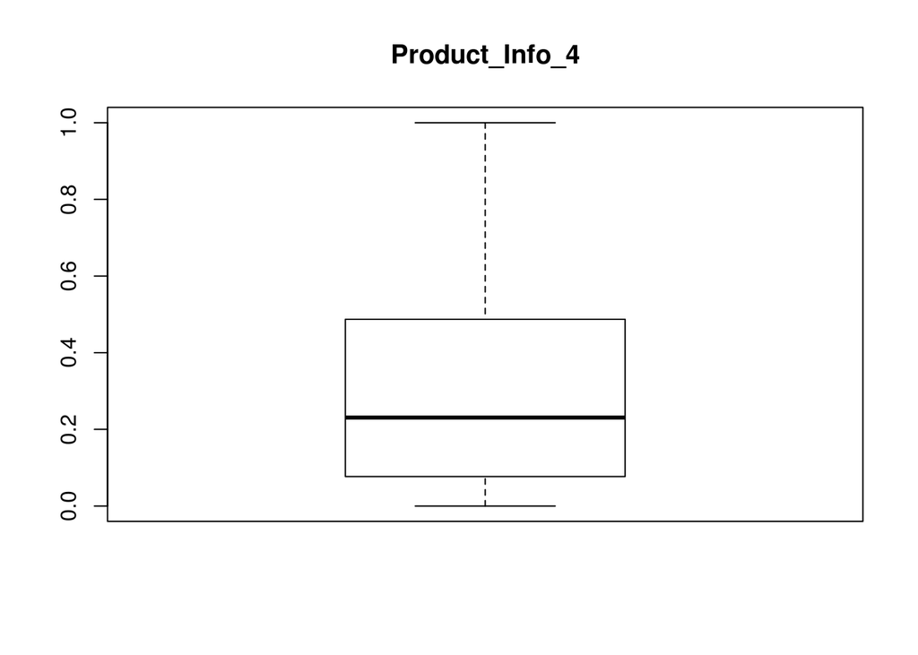

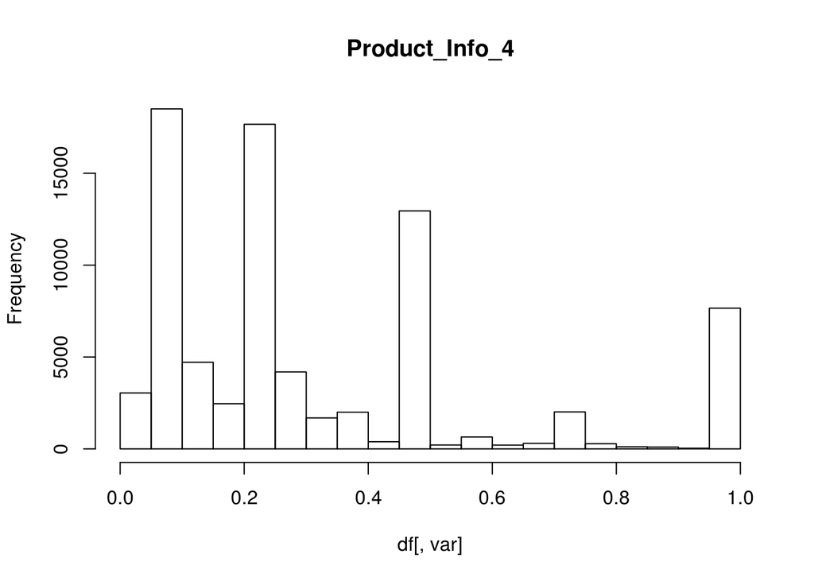

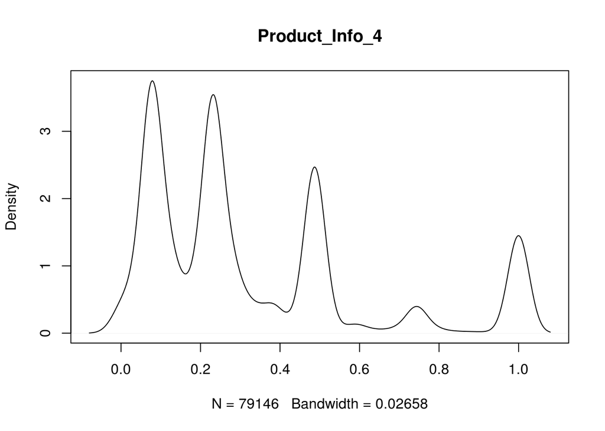

a numeric variable in the range [0,1]

```
##
## --- Product_Info_5 ---
## integer
##    Min. 1st Qu.  Median    Mean 3rd Qu.    Max.
##   2.000   2.000   2.000   2.007   2.000   3.000
## Table
##     2     3
## 78604   542
```

a two class unbalanced variable (2, 3). It should be converted to factor.

```
##
## --- Product_Info_6 ---
## integer
##    Min. 1st Qu.  Median    Mean 3rd Qu.    Max.
##   1.000   3.000   3.000   2.669   3.000   3.000
## Table
##     1     3
## 13093 66053
```

a two class unbalanced variable with values (1, 3). It should be converted to factor.

```
##
## --- Product_Info_7 ---
## integer
##    Min. 1st Qu.  Median    Mean 3rd Qu.    Max.
##   1.000   1.000   1.000   1.044   1.000   3.000
## Table
##     1     2     3
## 77422     2  1722
```

a three class very unbalanced variabes of values (1, 2, 3). There are only two data points with value = 2. Should these data points be removed fron the data set?. It should be converted to factor.

#### Ins_Age

Normalized age of applicant

```
##
## --- Ins_Age ---
## numeric
##    Min. 1st Qu.  Median    Mean 3rd Qu.    Max.
##  0.0000  0.2388  0.4179  0.4079  0.5672  1.0000
```

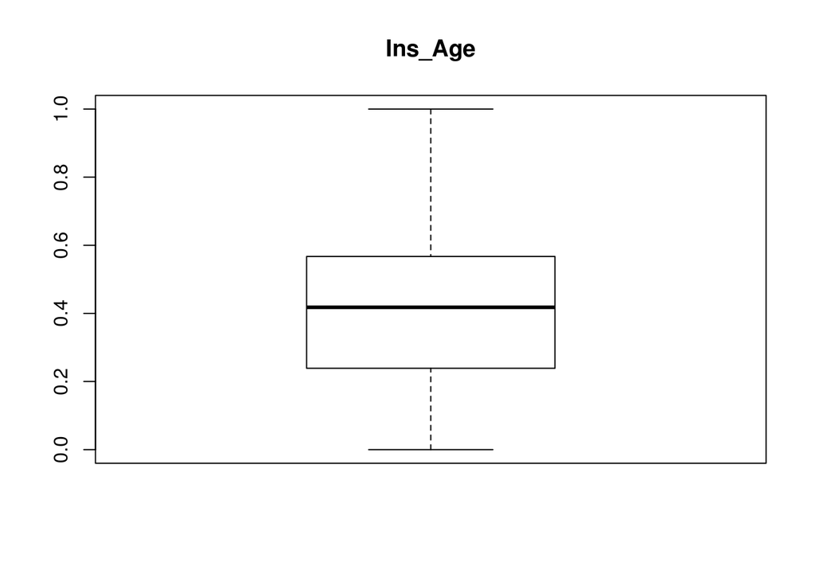

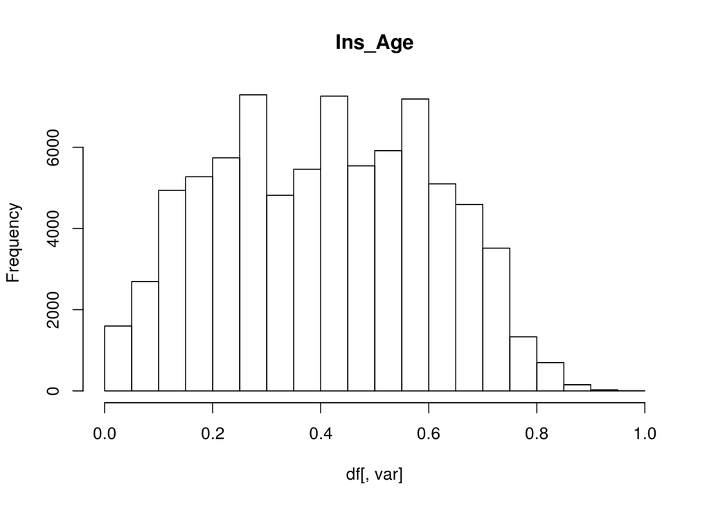

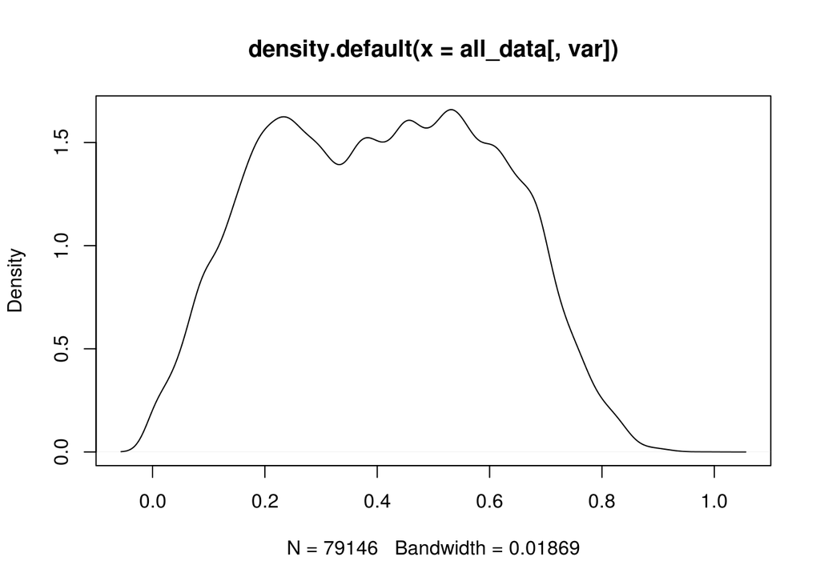

```
## 372 zero values
```

why so many zeroes? Are they valid data points (babies?) note that these are normalized variables. Zeros mean minimum values.

#### Ht

Normalized height of applicant

```
##
## --- Ht ---
## numeric
##    Min. 1st Qu.  Median    Mean 3rd Qu.    Max.
##  0.0000  0.6545  0.7091  0.7069  0.7636  1.0000
```

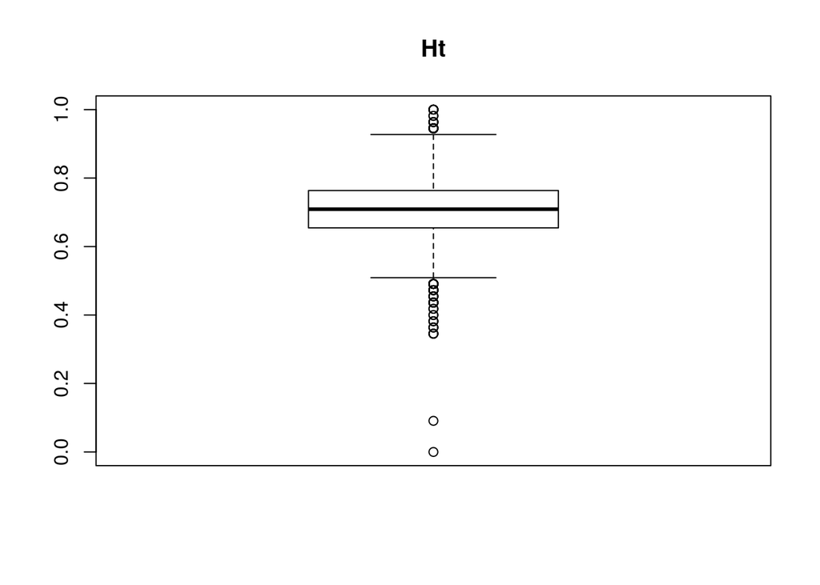

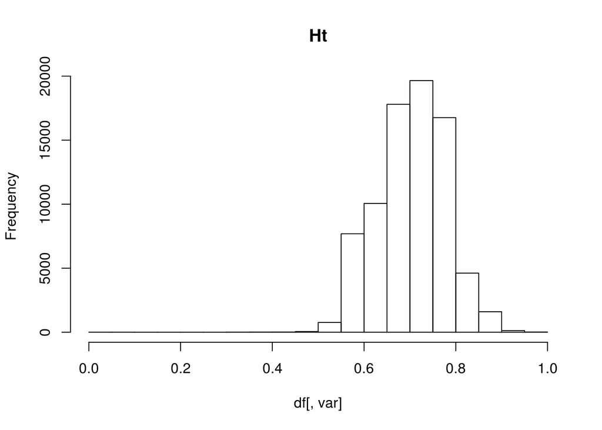

#### Wt

Normalized weight of applicant

```
##
## --- Wt ---
## numeric
##    Min. 1st Qu.  Median    Mean 3rd Qu.    Max.
##  0.0000  0.2259  0.2887  0.2926  0.3452  1.0000
```

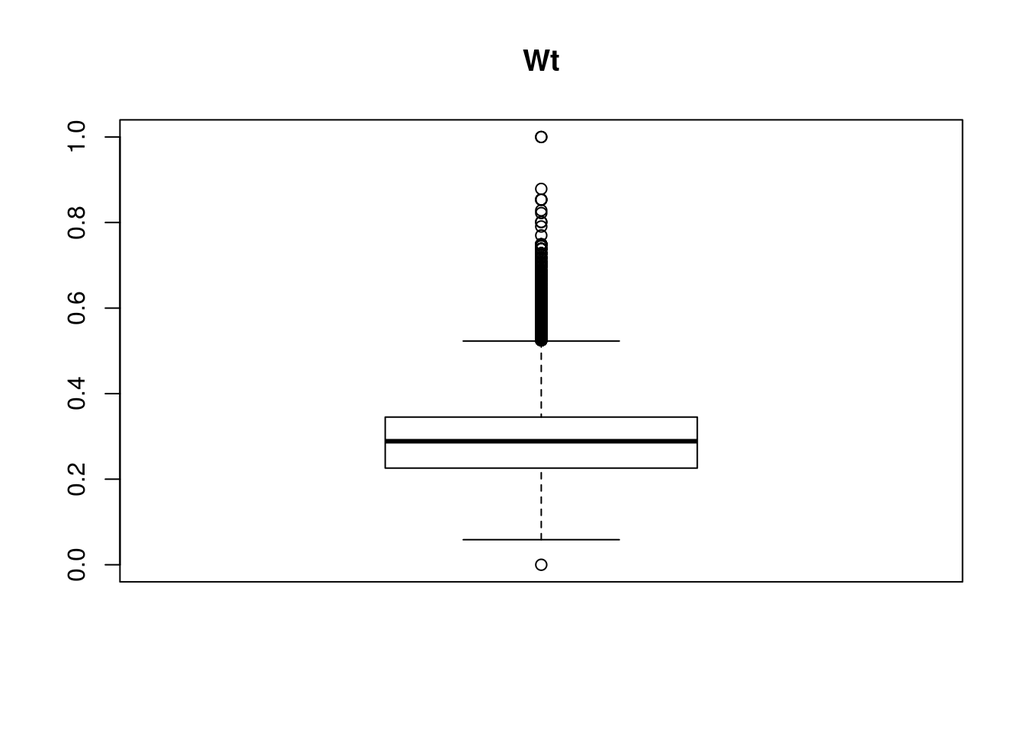

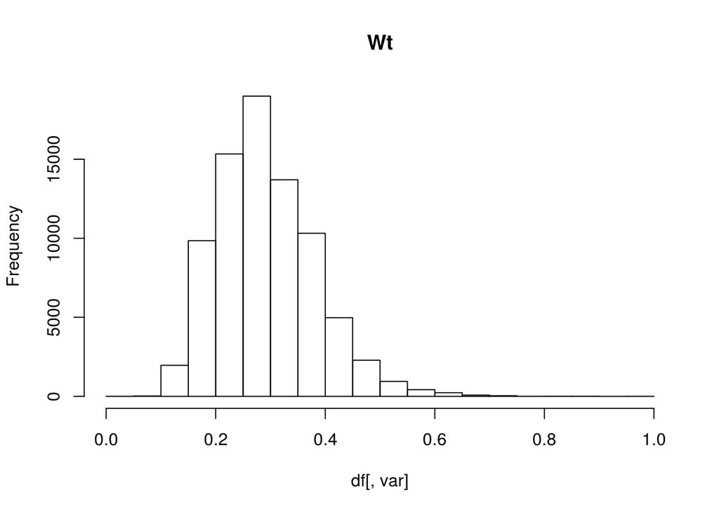

#### BMI

Normalized BMI of applicant

```
##
## --- BMI ---
## numeric
##    Min. 1st Qu.  Median    Mean 3rd Qu.    Max.
##  0.0000  0.3853  0.4525  0.4698  0.5337  1.0000
```

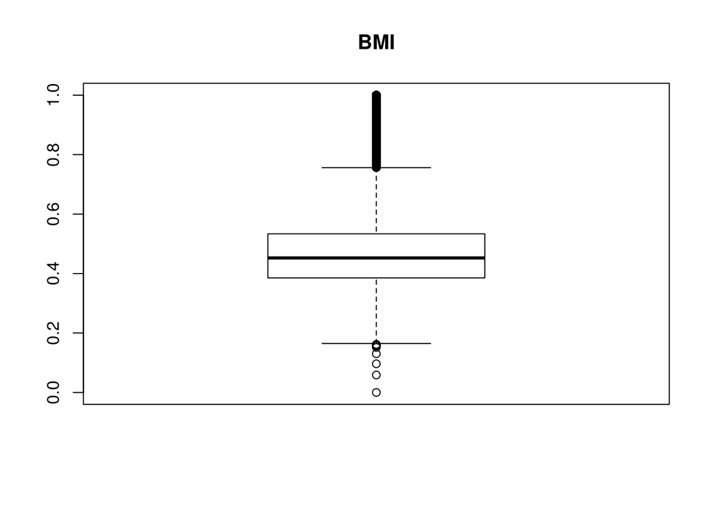

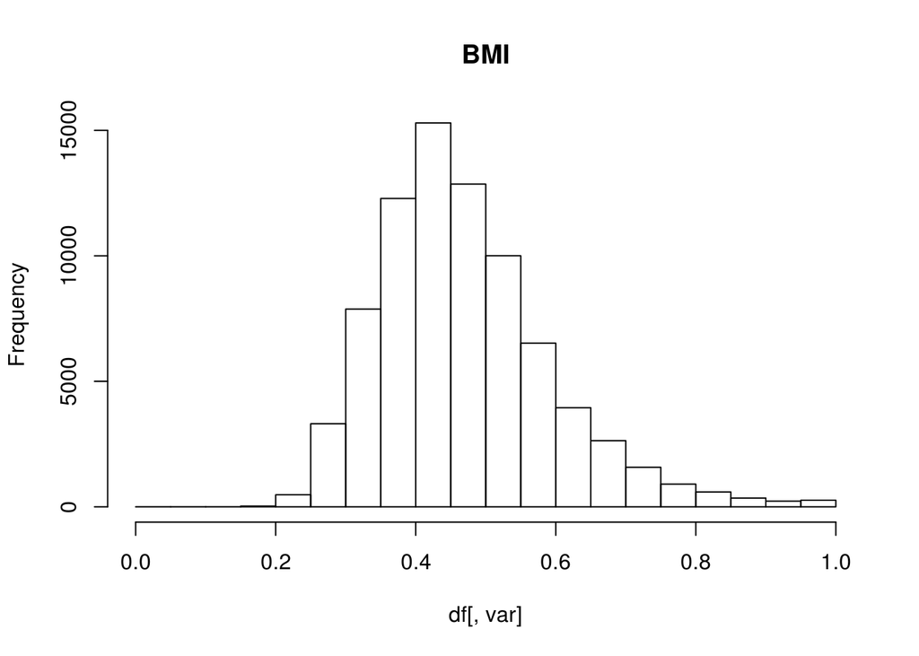

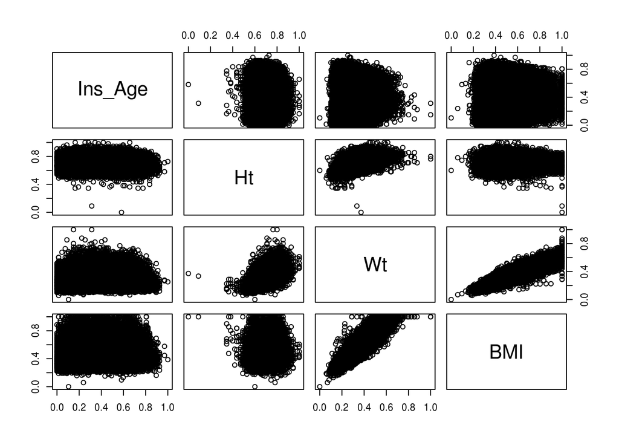

```r
pairs(all_data[, 9:12], pch = 21)
```

#### Employment_Info_1-6 A set of normalized variables relating to the employment history of the applicant.

```
##
## --- Employment_Info_1 ---
## numeric
##    Min. 1st Qu.  Median    Mean 3rd Qu.    Max.    NA's
## 0.00000 0.03500 0.06000 0.07793 0.10000 1.00000      22
```

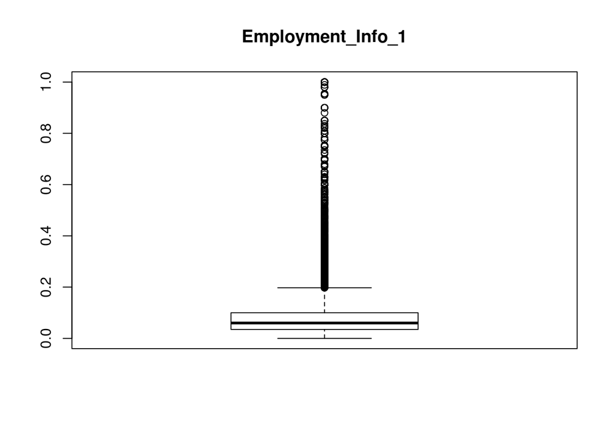

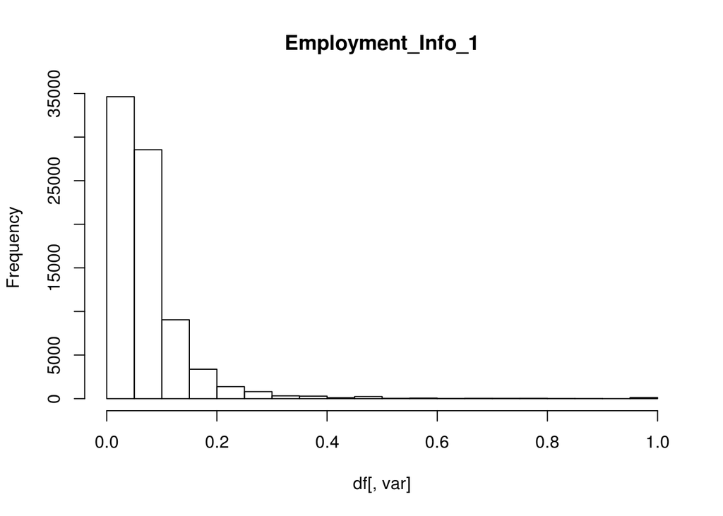

```
##
## --- Employment_Info_2 ---
## integer
##    Min. 1st Qu.  Median    Mean 3rd Qu.    Max.
##   1.000   9.000   9.000   8.592   9.000  38.000
## Table
##     1     2     3     4     5     6     7     8     9    10    11    12
## 12151    36  2275    12     2    21     8     1 46307   218   579 10079
##    13    14    15    16    17    18    19    20    21    22    23    24
##    27  6262   608    25     1     4     6    18     7     2     5     1
##    25    26    27    28    29    30    31    32    33    34    35    36
##     4     7    53     1     1     3     1   257     4     8     2    81
##    37    38
##    67     2
```

this variable has also 38 values, like Product_Info_3.

```r
length(unique(all_data[, var])) == length(unique(all_data[, 'Product_Info_3']))
```

```
## [1] TRUE
```

And the same values. Are both the same thing?

```r
sum(all_data[, var] == all_data[, 'Product_Info_3']) / nrow(all_data)
```

```
## [1] 0.0001263488
```

Nop.

this variable should be converted to factor.

```
##
## --- Employment_Info_3 ---
## integer
##    Min. 1st Qu.  Median    Mean 3rd Qu.    Max.
##   1.000   1.000   1.000   1.307   1.000   3.000
## Table
##     1     3
## 66995 12151
```

a binary unbalanced variable. It should be converted to factor.

```
##
## --- Employment_Info_4 ---
## numeric
##    Min. 1st Qu.  Median    Mean 3rd Qu.    Max.    NA's
##   0.000   0.000   0.000   0.006   0.000   1.000    8916
```

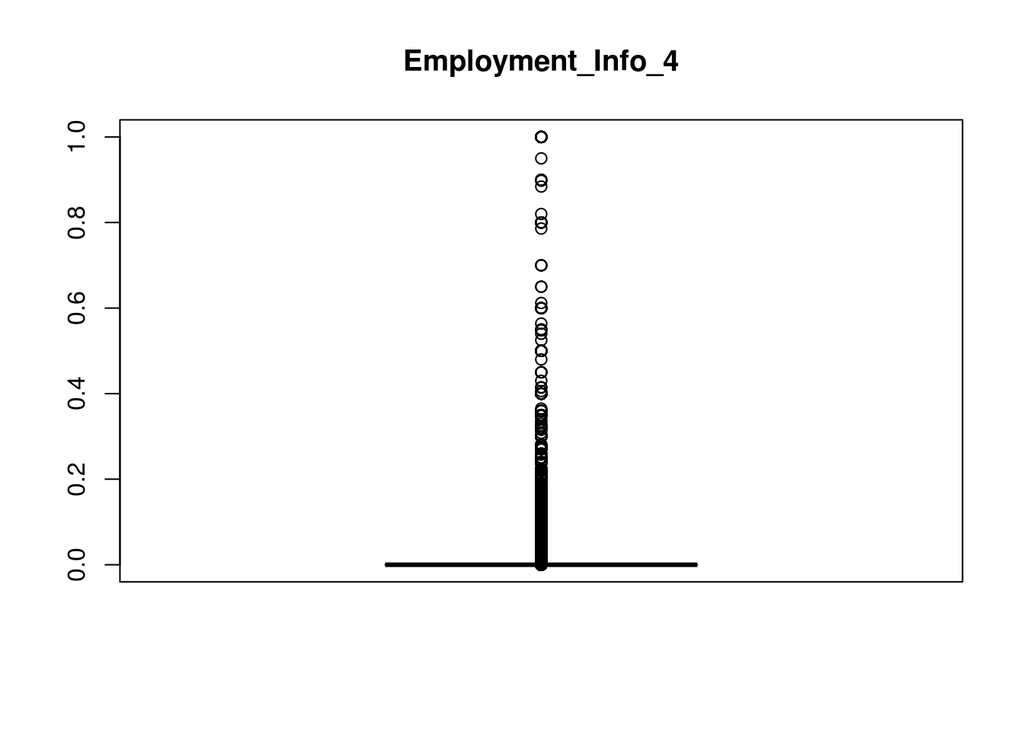

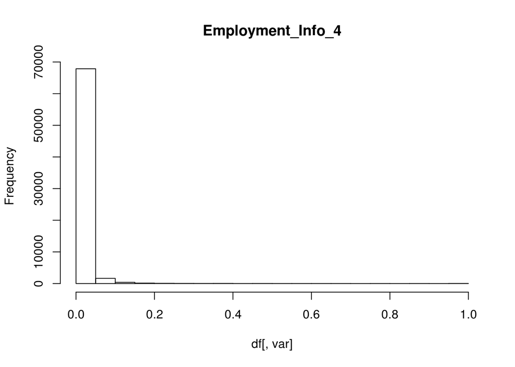

```
## 59616 Zeros
## 8916 NAs
```

numeric in the range [0,1] with a great proportion of NAs and lots of zeroes. there are 10614 non-zero data points.

```
##
## --- Employment_Info_5 ---
## integer
##    Min. 1st Qu.  Median    Mean 3rd Qu.    Max.
##   2.000   2.000   2.000   2.144   2.000   3.000
## Table
##     2     3
## 67711 11435
```

a binary unbalanced variable (2,3). It should be converted to factor.

```
##
## --- Employment_Info_6 ---
## numeric
##    Min. 1st Qu.  Median    Mean 3rd Qu.    Max.    NA's
##   0.000   0.060   0.250   0.363   0.580   1.000   14641
```

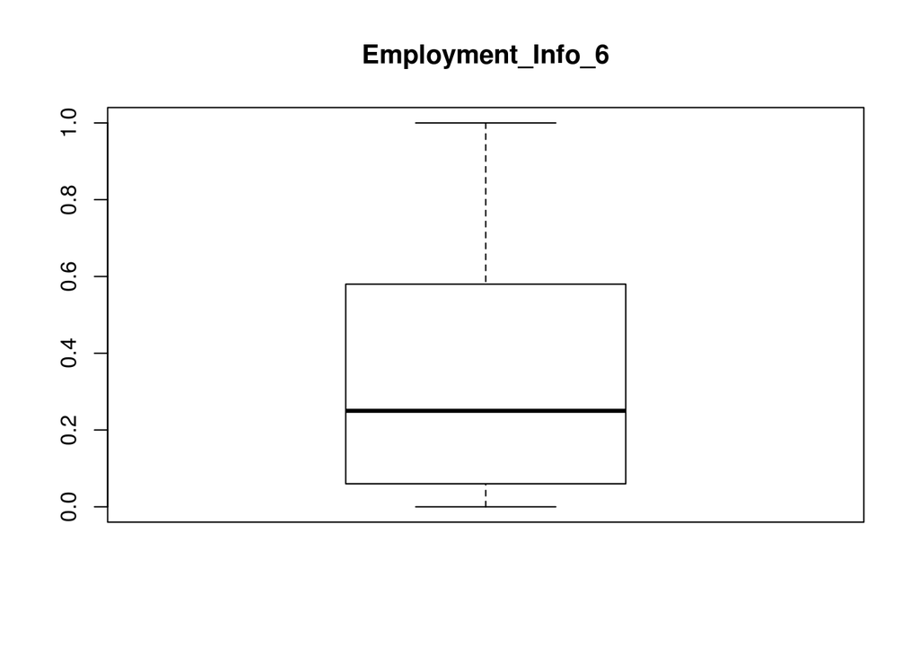

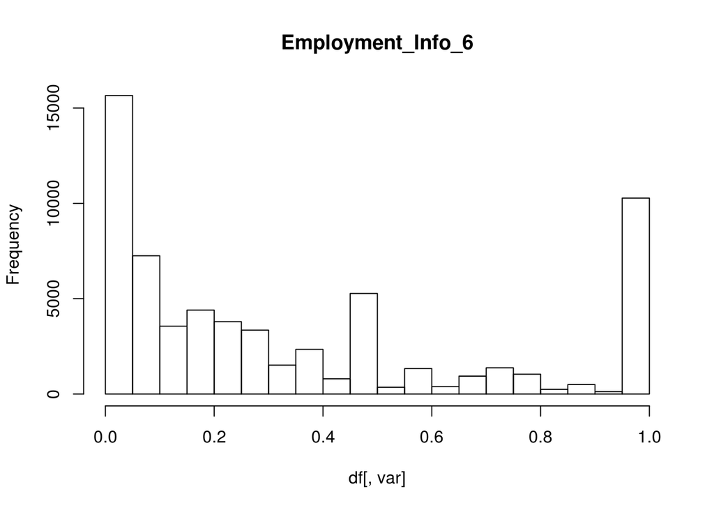

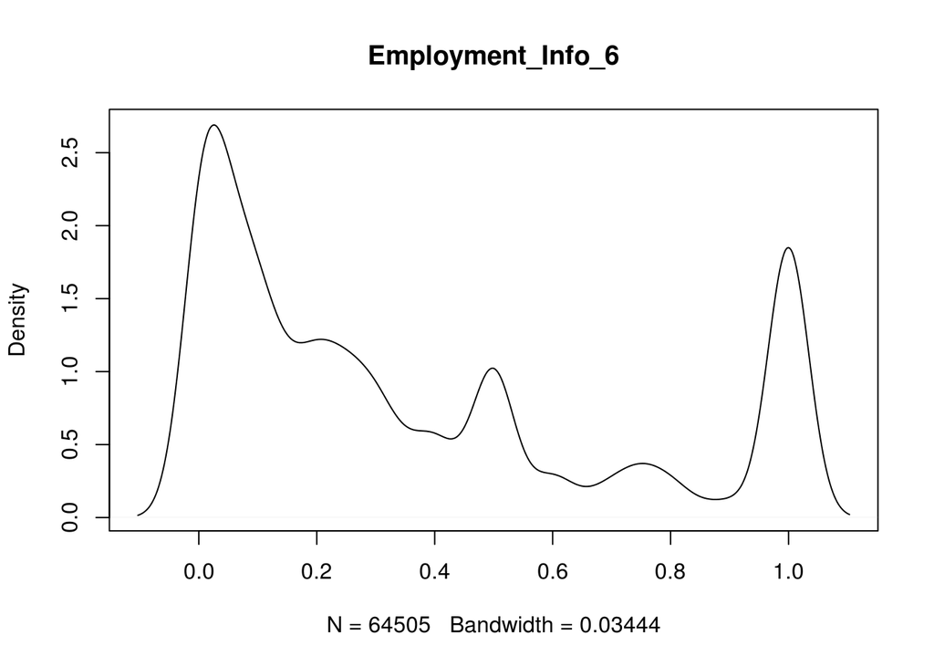

#### InsuredInfo_1-6

A set of normalized variables providing information about the applicant.

```
##
## --- InsuredInfo_1 ---
## integer
##    Min. 1st Qu.  Median    Mean 3rd Qu.    Max.
##   1.000   1.000   1.000   1.208   1.000   3.000
## Table
##     1     2     3
## 63045 15738   363
##
## --- InsuredInfo_2 ---
## integer
##    Min. 1st Qu.  Median    Mean 3rd Qu.    Max.
##   2.000   2.000   2.000   2.007   2.000   3.000
## Table
##     2     3
## 78559   587
##
## --- InsuredInfo_3 ---
## integer
##    Min. 1st Qu.  Median    Mean 3rd Qu.    Max.
##   1.000   3.000   6.000   5.801   8.000  11.000
## Table
##     1     2     3     4     5     6     7     8     9    10    11
##  1127  7254 21704  1231   273 12821   398 27969    23  1402  4944
##
## --- InsuredInfo_4 ---
## integer
##    Min. 1st Qu.  Median    Mean 3rd Qu.    Max.
##   2.000   3.000   3.000   2.886   3.000   3.000
## Table
##     2     3
##  9030 70116
##
## --- InsuredInfo_5 ---
## integer
##    Min. 1st Qu.  Median    Mean 3rd Qu.    Max.
##   1.000   1.000   1.000   1.028   1.000   3.000
## Table
##     1     3
## 78042  1104
##
## --- InsuredInfo_6 ---
## integer
##    Min. 1st Qu.  Median    Mean 3rd Qu.    Max.
##   1.000   1.000   1.000   1.412   2.000   2.000
## Table
##     1     2
## 46528 32618
```

all InsuredInfo variables are discrete variables of just a few values and should be converted to factor.

#### Insurance_History_1-9

A set of normalized variables relating to the insurance history of the applicant.

```
##
## --- Insurance_History_1 ---
## integer
##    Min. 1st Qu.  Median    Mean 3rd Qu.    Max.
##   1.000   1.000   2.000   1.722   2.000   2.000
## Table
##     1     2
## 21980 57166
##
## --- Insurance_History_2 ---
## integer
##    Min. 1st Qu.  Median    Mean 3rd Qu.    Max.
##   1.000   1.000   1.000   1.054   1.000   3.000
## Table
##     1     2     3
## 77001     1  2144
##
## --- Insurance_History_3 ---
## integer
##    Min. 1st Qu.  Median    Mean 3rd Qu.    Max.
##   1.000   1.000   3.000   2.156   3.000   3.000
## Table
##     1     2     3
## 33396     1 45749
##
## --- Insurance_History_4 ---
## integer
##    Min. 1st Qu.  Median    Mean 3rd Qu.    Max.
##   1.000   1.000   2.000   1.948   3.000   3.000
## Table
##     1     2     3
## 37568  8109 33469
##
## --- Insurance_History_5 ---
## numeric
##    Min. 1st Qu.  Median    Mean 3rd Qu.    Max.    NA's
##       0       0       0       0       0       1   33501
```

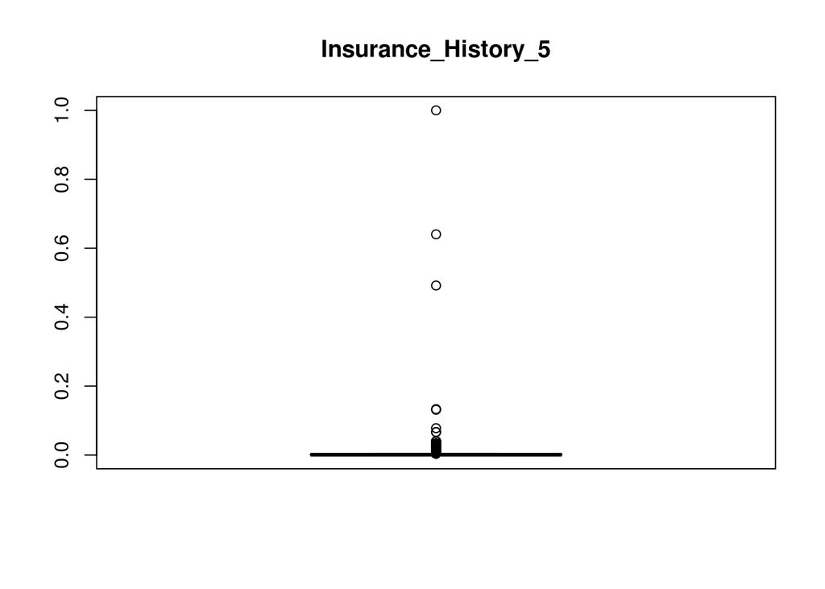

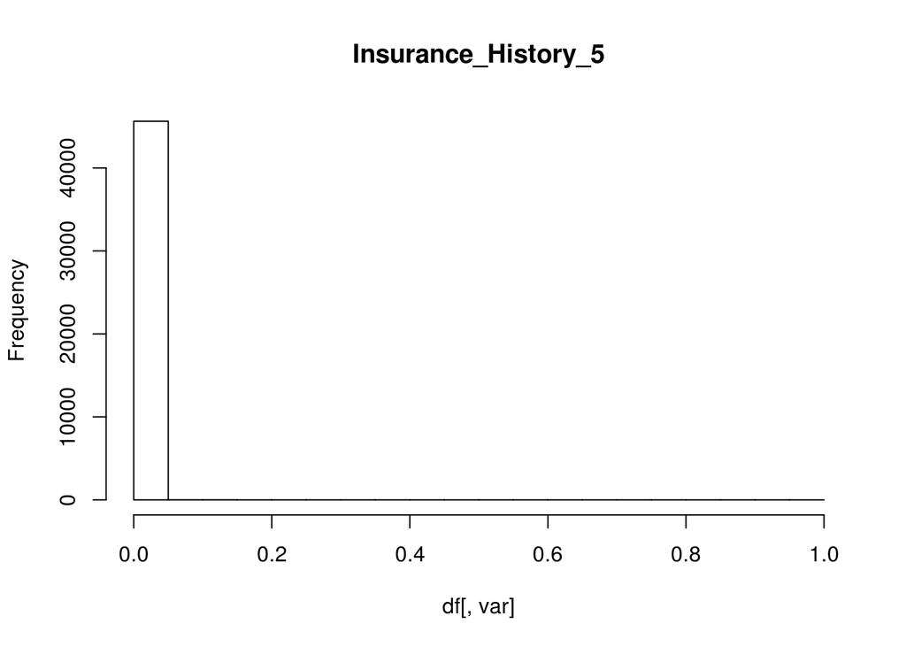

```
##
## --- Insurance_History_7 ---
## integer
##    Min. 1st Qu.  Median    Mean 3rd Qu.    Max.
##   1.000   1.000   1.000   1.899   3.000   3.000
## Table
##     1     2     3
## 41438  4236 33472
##
## --- Insurance_History_8 ---
## integer
##    Min. 1st Qu.  Median    Mean 3rd Qu.    Max.
##   1.000   1.000   2.000   2.046   3.000   3.000
## Table
##     1     2     3
## 21030 33467 24649
##
## --- Insurance_History_9 ---
## integer
##    Min. 1st Qu.  Median    Mean 3rd Qu.    Max.
##   1.000   2.000   2.000   2.414   3.000   3.000
## Table
##     1     2     3
##   692 44982 33472
```

[figure not shown]

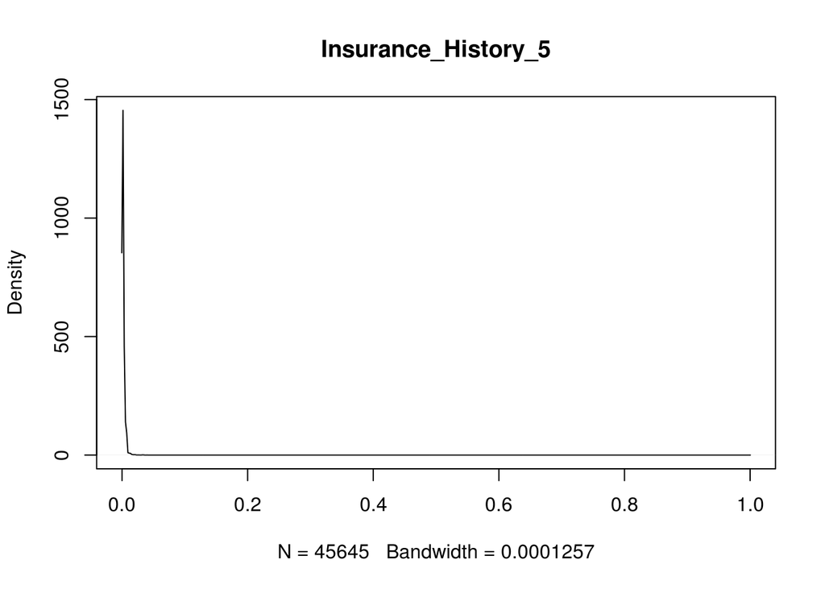

Insurance_History_5 seens to have a few outliers with values close to 1. All other variables in the group should be converted to factor.

#### Family_Hist_1-5

A set of normalized variables relating to the family history of the applicant.

```
##
## --- Family_Hist_1 ---
## integer
##    Min. 1st Qu.  Median    Mean 3rd Qu.    Max.
##   1.000   2.000   3.000   2.687   3.000   3.000
## Table
##     1     2     3
##   714 23376 55056
##
## --- Family_Hist_2 ---
## numeric
##    Min. 1st Qu.  Median    Mean 3rd Qu.    Max.    NA's
##    0.00    0.36    0.46    0.47    0.58    1.00   38536
```

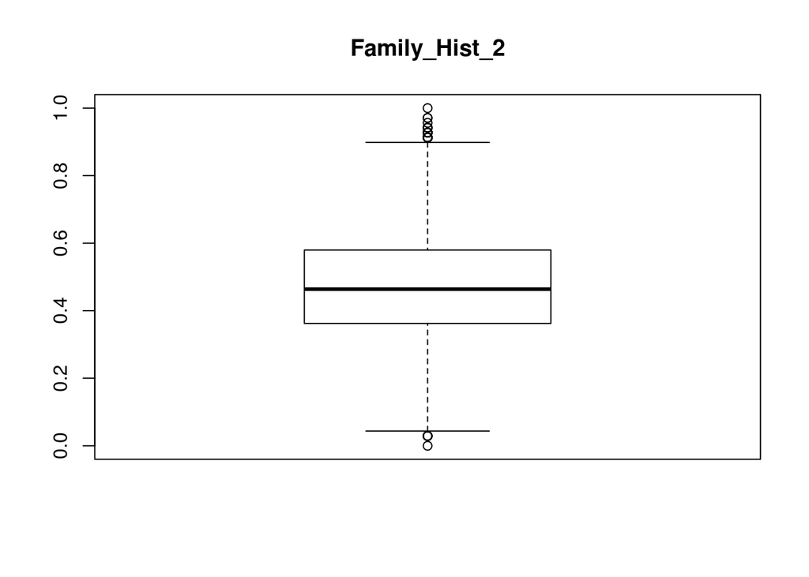

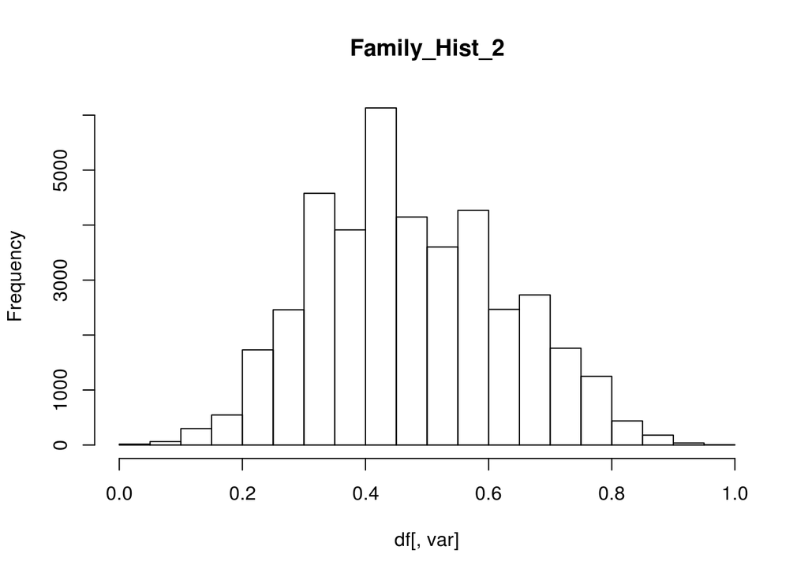

```
##
## --- Family_Hist_3 ---
## numeric
##    Min. 1st Qu.  Median    Mean 3rd Qu.    Max.    NA's
##    0.00    0.41    0.52    0.50    0.61    1.00   45305
```

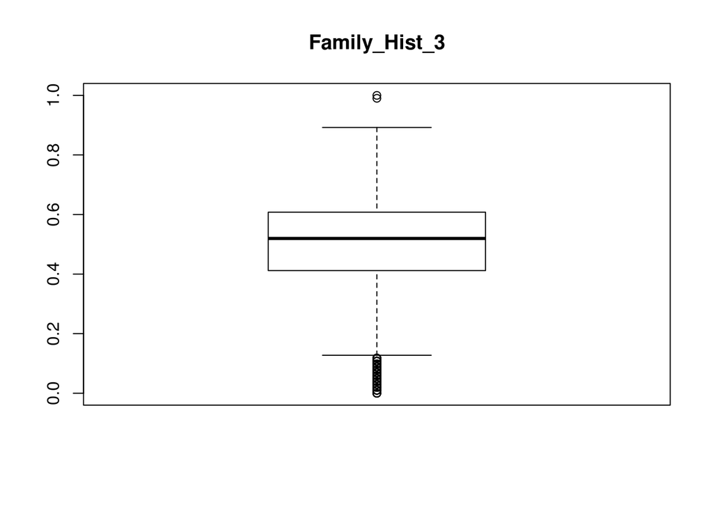

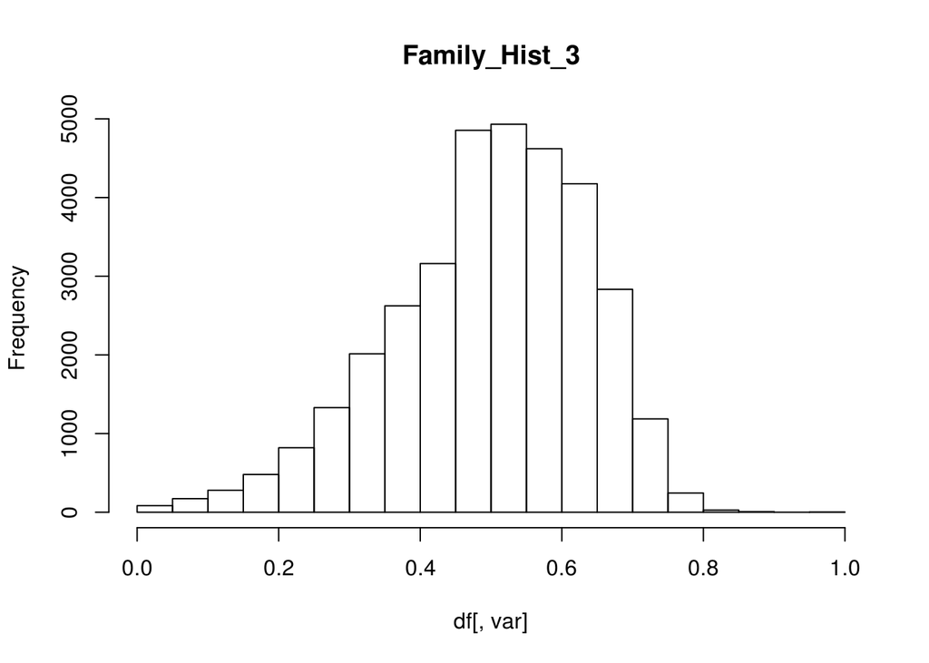

```
##
## --- Family_Hist_4 ---
## numeric
##    Min. 1st Qu.  Median    Mean 3rd Qu.    Max.    NA's
##   0.000   0.324   0.437   0.445   0.563   1.000   25861
```

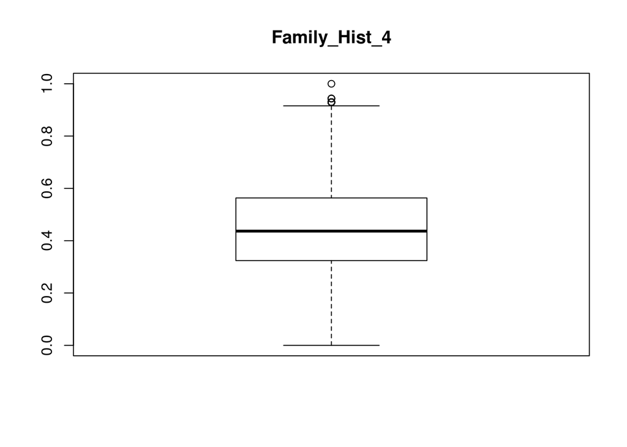

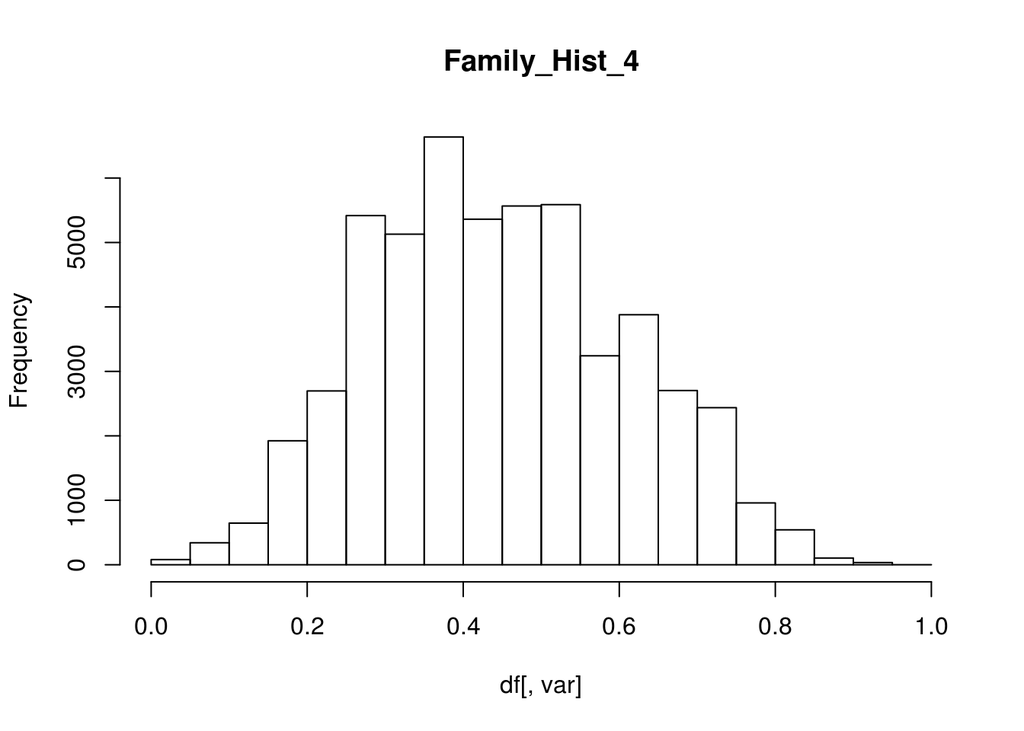

```
##
## --- Family_Hist_5 ---
## numeric
##    Min. 1st Qu.  Median    Mean 3rd Qu.    Max.    NA's
##    0.00    0.41    0.51    0.49    0.58    1.00   55435
```

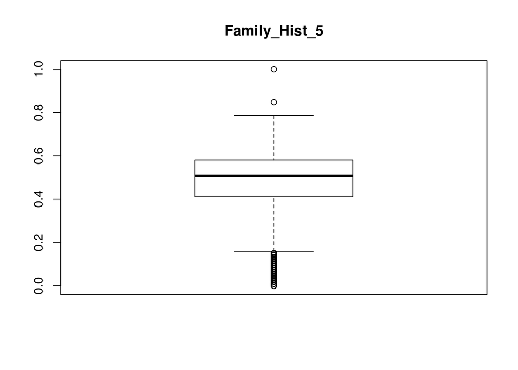

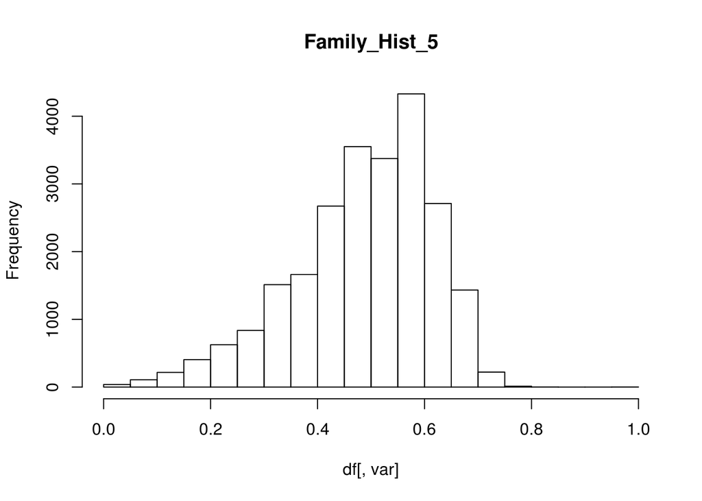

convert Family Hist 1 to factor. Watch out with NAs in the rest of the group.